# Trendy - testy statystyczne

pogRomcy danych

sezon 2 / odcinek 15  
[Przemysław Biecek @ Uniwersytet Warszawski](http://biecek.pl/)  
Naciśnij `A` by zamienić slajdy na ciągły tekst.  
Naciśnij `T` by wyświetlić spis treści.

# O czym jest ten odcinek?

W poprzednim odcinku poznaliśmy metodę wyznaczania współczynników $a_0$ i $a_1$ trendu liniowego.

Dzięki temu, możemy np. ocenić czy obserwowana wartość (np. ocena odcinka) średnio rośnie czy maleje.

Czasem jednak ocena współczynnika $a_1$, opisująca tempo wzrostu jest bardzo bliska wartości $0$. Możemy wtedy zadać dodatkowe pytanie, czy obserwowany wzrost/spadek nie jest wynikiem przypadkowych fluktuacji?

Jak odpowiedzieć na to pytanie? Kiedy obserwowany trend może być wynikiem przypadkowego ułożenia wartości, a kiedy jest wynikiem prawdziwej tendencji?

Tutaj ponownie pojawia się statystyka. Używając takich narzędzi jak *test dla współczynnika trendu* możemy ocenić na ile ocena współczynnika $a_1$ jest istotnie różna od 0 (a więc jej znak jest nieprzypadkowy).

W tym odcinku, na przykładzie danych z serwisu IMDB (Internet Movie Database), pokażemy jak działa procedura testowania trendu w danych.

# Zbiór danych do pracy

W bazie danych o filmach IMDB (Internet Movie Database) znaleźć można dane o serialach. Dla każdego odcinka serialu dostępne są średnie oceny użytkowników.

Przykładowo, na stronie http://www.imdb.com/title/tt0903747/epdate?ref_=ttep_ql_4 znajdują się oceny serialu *Breaking Bad*.

Dane te zostały pobrane z Internetu i przygotowane tak, że teraz są dostępne w zbiorze danych `serialeIMDB` w pakiecie `PogromcyDanych`, który towarzyszy temu kursowi.

Wybierzemy z tego zbioru danych tylko wartości dla serialu `Breaking Bad`.

```r
library(PogromcyDanych)
# wybieramy dane o jednym serialu, dwie kolumny
tylkoBreakingBad <- serialeIMDB %>%
  filter(serial == "Breaking Bad") %>% select(id, ocena)
# wyświetlamy pierwsze wiersze
head(tylkoBreakingBad)
```

```
##   id ocena
## 1  1   8.7
## 2  2   8.2
## 3  3   8.3
## 4  4   7.9
## 5  5   7.9
## 6  6   8.7
```

# Dane i trend liniowy

W poprzednim odcinku pokazaliśmy jak wyznaczyć współczynniki trendu liniowego z użyciem funkcji `lm()`. Przypomnijmy, aby otrzymać punkt startowy trendu, oraz tempo zmiany co odcinek, należało wykorzystać instrukcję.

```r
lm(ocena~id, tylkoBreakingBad)$coef
```

```
## (Intercept)          id
##  7.90222105  0.01836267
```

Dla przypomnienia, graficzna ilustracja danych o tym serialu.

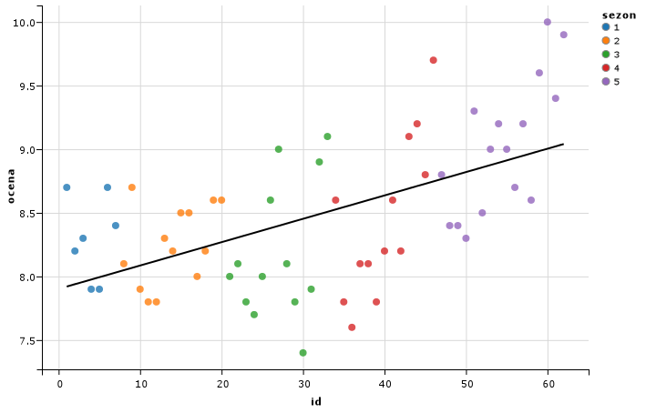

# Czy wzrost ocen dla Breaking Bad to przypadek? Test permutacyjny

Dla serialu Breaking Bad widzimy wzrostową tendencję wynoszącą ponad 0.018.

Na wykresie wygląda to jak stabilny trend rosnący, ale czy poza oceną wzrokową możemy liczbowo ocenić czy ten trend nie jest przypadkowy?

Czy taka tendencja może nas przekonać, że faktycznie odcinki w tym serialu są coraz lepsze (a w każdym razie coraz wyżej oceniane)?

Statystycy opracowali wiele testów aby badać istotność trendu / tendencji. W większości przypadków te testy dają zbliżone wyniki, więc zamiast przedstawiać ich leksykon wyjaśnimy na jednym przykładzie na czym polega testowanie. Przedstawimy tak zwany test permutacyjny do badania trendu.

Pomysł na ocenę, czy trend ma istotną tendencje wzrostową, składa się z trzech kroków. Przedstawmy je jeden po drugim.

### Krok 1: Postaw hipotezę, określ co chcesz porównać

Będziemy testować hipotezę (=przypuszczenie), że współczynnik wzrostu jest istotnie różny od zera, czyli od braku trendu.

Tę hipotezę, sformujmy w następujący sposób: *Czy obserwowana wartość współczynnika wzrostu jest wystarczająco duża, by uznać ją za istotną?*

### Krok 2: Określ miarę wielkości

Ustalmy, że wielkość współczynnika trendu będziemy mierzyć za pomocą wartości bezwzględnej tego współczynnika. Zarówno bowiem silny ujemny jak i silny dodatni trend uznamy za różny od zera.

Wartość bezwzględną można wyznaczyć funkcją `abs()`.

```r
(wspolczynnikiTrendu <- lm(ocena~id, tylkoBreakingBad)$coef)
```

```
## (Intercept)          id
##  7.90222105  0.01836267
```

```r
# moduł współczynnika wzrostu
(modulBreakingBad <- abs(wspolczynnikiTrendu[2]))
```

```
##         id
## 0.01836267
```

# Czy wzrost ocen dla Breaking Bad to przypadek? Test permutacyjny

### Krok 3: Porównaj zaobserwowany trend z trendem w sytuacji gdyby nie było zależności

Wciąż nie wiemy, czy `0.0183` to duży wzrost czy mały.

Musimy go z czymś porównać. Najlepiej by było porównać ją z wartościami, które byśmy obserwowali gdyby nie było prawdziwego trendu.

Ale skąd wiadomo, ile wynosiłby ten współczynnik gdyby nie było trendu? Możemy to oszacować w następujący sposób

- [I] Wymieszamy losowo wartości ocen. Dzięki temu otrzymamy sekwencje ocen o której wiemy, że nie ma w niej żadnego systematycznego trendu (losowo je wymieszaliśmy), a ewentualna wielkość współczynnika trendu wynika z losowych fluktuacji,
- [II] Policzymy jak duży jest trend dla tych nowo wylosowanych grup,
- [III] Powtórzymy kroki [I] i [II] wielokrotnie, aby zobaczyć jak duże wartości może przyjmować trend w sytuacji gdy jest on wynikiem losowych fluktuacji. Powtórzmy te kroki wiele wiele razy, np. 99 999 razy.

Liczenie wartości trendu dla losowo pomieszanych danych jest realizowane przez poniższy kod.

```r
# funkcja replicate() powtarza drugie wyrażenie tyle razy, ile wynosi pierwszy argument (=99999)
trendy <- replicate(99999, {
  # wymieszaj losowo wartości, robi to funkcja sample()
  tylkoBreakingBad$wymieszane <- sample(tylkoBreakingBad$ocena)

  # wyznacz moduł współczynnika wzrostu dla losowo wymieszanych danych
  wspolczynnikiTrendu <- lm(wymieszane~id, tylkoBreakingBad)$coef
  abs(wspolczynnikiTrendu[2])
})
# modulBreakingBad jest też jedną z możliwych permutacji, dodajmy go do wyniku
trendy <- c(trendy, modulBreakingBad)
# wyświetl pierwsze 20 z tak otrzymanych wartości
head(trendy, 20)
```

```
##           id           id           id           id           id
## 0.0031124877 0.0021203193 0.0069552517 0.0052781345 0.0046687316
##           id           id           id           id           id
## 0.0051471884 0.0067789781 0.0047493138 0.0022009015 0.0045931858
##           id           id           id           id           id
## 0.0054594445 0.0027095767 0.0014706253 0.0051119337 0.0048097504
##           id           id           id           id           id
## 0.0005791846 0.0004633477 0.0043161844 0.0073531263 0.0021958651
```

# Czy wzrost ocen dla Breaking Bad to przypadek? Porównanie wartości

Możemy teraz wartość `modulBreakingBad` porównać z wektorem wartości referencyjnych, które są w wektorze `trendy`.

O wektorze `trendy` można myśleć jak o wielkościach wzrostów, jakich spodziewać się możemy gdy próby różnią się wyłącznie przypadkową zmiennością. Gdyby `modulBreakingBad` był znacząco większy niż wartości z wektora `trendy`, to byłby to silny argument za tym, że trend rosnący w ocenie odcinków *Breaking Bad* nie jest przypadkowy.

Porównajmy na wykresie wielkości różnic dla losowych fluktuacji (na szaro) z obserwowaną różnicą (na czerwono).

Jak widzimy, obserwowana wartość wzrostu ocen dla serialu *Breaking Bad* jest znacznie większa niż wzrosty, które byłoby widać, gdyby nie było żadnej prawdziwej tendencji.

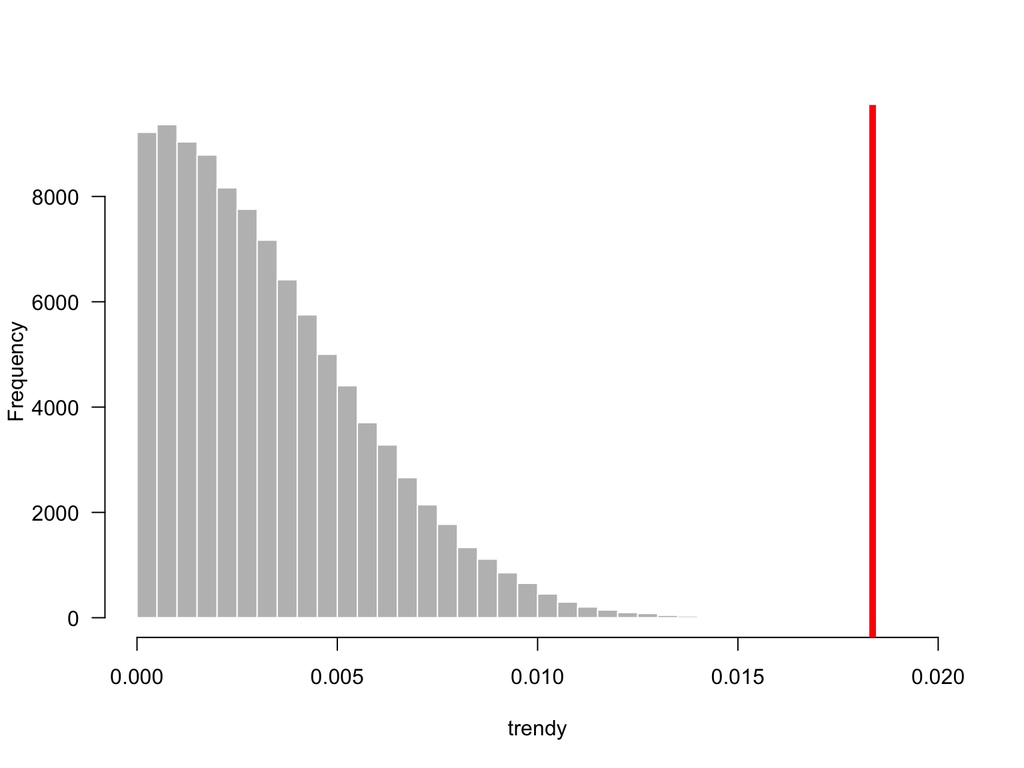

```r
# jak wyglądają przypadkowe współczynniki
hist(trendy, 50, col="grey", main="", las=1, border="white", xlim=c(0, 0.02))
# dorysuj na czerwono współczynnik dla BreakingBad
abline(v=modulBreakingBad, col="red", lwd=5)
```

# Czy wzrost ocen dla Breaking Bad to przypadek? P-wartość

Wykres pomaga w zobaczeniu jak wyglądają przypadkowe współczynniki na tle obserwowanej wartości.

Ale aby podjąć decyzje lepiej mieć jedną liczbę. Jaką?

Policzmy jaka część trendów dla losowych fluktuacji jest większa lub równa niż obserwowany trend dla *Breaking Bad*. Ta wartość nazywa się *wartością p* lub *p-wartością*.

```r
# p-wartość
mean(trendy >= modulBreakingBad)
```

```
## [1] 1e-05
```

Tylko 0.00001? Czyli, gdy zaburzaliśmy losowo oceny to nie udało się uzyskać tak dużego wzrostu jak w przypadku serialu *Breaking Bad*. Jedna wartość, przez którą obserwowana średnia różni się od zera, to wynik trendu obserwowanego bez permutacji, który dodaliśmy do wektora `trendy`.

To porównanie, pokazujące jak dużą wartością `modulBreakingBad` na tle przypadkowych wartości zapisanych w wektorze `trendy` jest przekonującym argumentem, że obserwowany wzrost ocen dla *Breaking Bad* nie jest przypadkowy.

# A co z Przyjaciółmi?

A jak wygląda trend dla serialu *Friends*?

Co do wartości to wynosi niewiele ponad 0.000432, czyli jest również dodatni, ale mniejszy niż dla Breaking Bad.

Hipoteza, którą chcemy sprawdzić, to czy ten trend istotnie większy od zera?

```r
tylkoFriends <- serialeIMDB %>% filter(serial == "Friends") %>% select(id, ocena)
# wyznaczmy współczynniki trendu liniowego dla serialu Przyjaciele
lm(ocena~id, tylkoFriends)$coef
```

```
##  (Intercept)           id
## 8.4562918838 0.0004325633
```

Oraz poglądowy rysunek prezentujący ten trend.

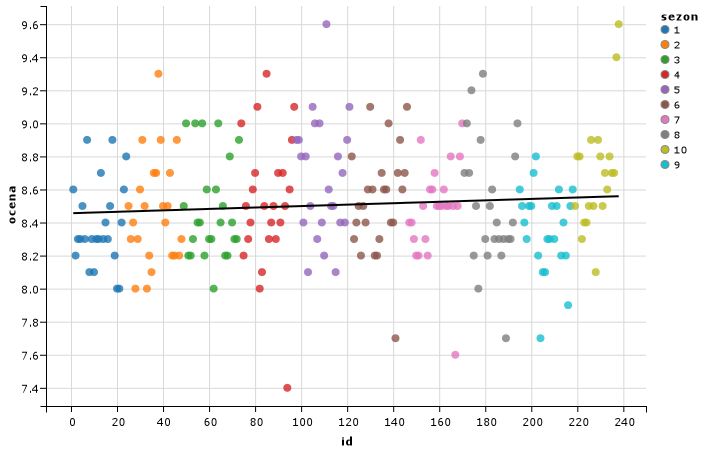

# A co z Przyjaciółmi? Testowanie

Zweryfikujemy hipotezę o istotności trendu w ten sam sposób co dla serialu *Breaking Bad*.

Przeprowadźmy te same obliczenia, tylko że dla serialu *Przyjaciele*. Wyniki porównamy w ten sam sposób co poprzednio.

```r
# trend dla serialu Friends
wspolczynnikiTrendu <- lm(ocena~id, tylkoFriends)$coef
(modulFriends <- abs(wspolczynnikiTrendu[2]))
```

```
##           id
## 0.0004325633
```

```r
# losowe współczynniki trendu w liczbie 99 999
trendy <- replicate(99999, {
  tylkoFriends$wymieszane <- sample(tylkoFriends$ocena)
  wspolczynnikiTrendu <- lm(wymieszane~id, tylkoFriends)$coef
  abs(wspolczynnikiTrendu[2])
})
# modulFriends jest też jedną z możliwych permutacji, dodajmy go do wyniku
trendy <- c(trendy, modulFriends)
head(trendy, 20)
```

```
##           id           id           id           id           id
## 2.272971e-04 1.345446e-04 4.125351e-04 6.940862e-04 6.012447e-04
##           id           id           id           id           id
## 2.470137e-05 3.844067e-04 1.174539e-04 6.296401e-04 1.921366e-04
##           id           id           id           id           id
## 3.662924e-05 3.823149e-05 3.208953e-05 1.411316e-04 4.853485e-04
##           id           id           id           id           id
## 2.592531e-04 2.274306e-05 1.400634e-04 2.033524e-04 6.101906e-05
```

Mamy wyznaczony referencyjny wektor wzrostów `trendy`. Jak na jego tle wygląda obserwowane 0.00043?

# A co z Przyjaciółmi? Testowanie

Wykres z wartościami referencyjnymi i wzrostem dla serialu Przyjaciele.

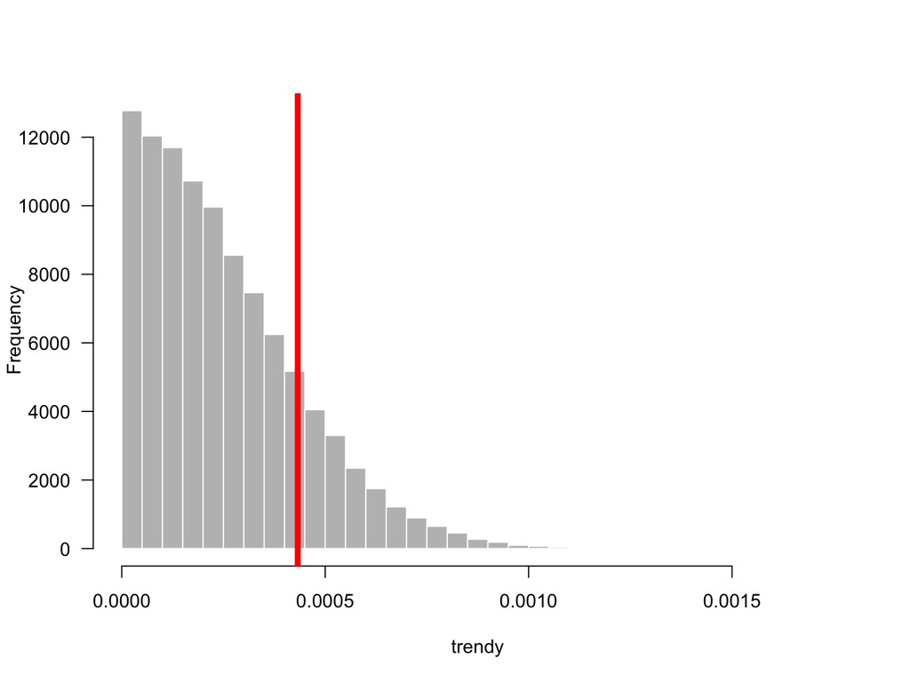

```r
hist(trendy, 50, col="grey", main="", las=1, border="white")
abline(v=modulFriends, col="red", lwd=5)
```

# A co z Przyjaciółmi? P-wartość

Już graficzna ocena sytuacji, pokazuje, że mamy do czynienia z inną zależnością niż dla *Breaking Bad*. Tym razem dosyć często się zdarza, żeby losowe permutacje wektora ocen owocowały większym współczynnikiem wzrostu niż ten, który obserwujemy dla serialu Przyjaciele.

Jak opisać te różnice jedną liczbą? Jak często obserwuje się wartość większą lub równą.

```r
# p-wartość
mean(trendy >= modulFriends)
```

```
## [1] 0.17079
```

Dla serialu *Friends* nawet gdy losujemy wartości ocen, a więc mamy czystko przypadkowe sekwencje, to w ponad 17 procentach przypadków obserwujemy trend większy niż `0.00043`. Czy to oznacza, że rosnący trend jest czysto przypadkowy?

Pewności nie ma, ale raczej jesteśmy skłonni uznać, że obserwowany trend nie jest istotnie różny od zera.

Za próg przyjmuje się często 0.05 (głównie z powodów historycznych, ale już tak się utarło). Co znaczy tyle, że uznaje się trend za nieprzypadkowy jeżeli jest mniejszy o co najwyżej 5% wartości, które można by przypadkowo zaobserwować (5% wartości to jedna na 20).

Przyjmując za próg 0.05, p-wartość którą obserwujemy dla trendu dla sezonu Przyjaciele jest wyższa, więc raczej przyjmiemy hipotezę, że ten trend nie jest isotnie różny od zera.

# Podsumowanie testowania

Wyniki, które otrzymaliśmy dla serialu *Breaking Bad* są inne niż dla serialu *Friends*.

W przypadku serialu *Breaking Bad* próbowaliśmy 99 999 razy losowo pomieszać dane by na pomieszanych zaobserwować wzrost większy, niż w przypadku oryginalnej kolejności. To się nie udało, co przekonało nas, że obserwowany trend dla *Breaking Bad* jest *istotnie większy od przypadkowego (=0)*.

W przypadku serialu *Friends* próbowaliśmy tego samego. Z tą różnicą, że udawało się dosyć często w wyniku losowych permutacji uzyskać współczynniki trendu większe, niż dla oryginalnych danych.

P-wartością nazywamy statystykę, opisującą jaka część losowo wygenerowanych trendów jest większa, niż trend w oryginalnych danych. Przyjęliśmy też, że jeżeli p-wartość będzie mała, np. mniejsza niż 0.05 (arbitralny wybór, ale się przyjęło) to uznamy, że trend jest istotny.

Tyle, że dla serialu *Friends* obserwowana p-wartość jest znacznie większa niż 0.05, przez co uznamy, że trend nie jest istotnie różny od przypadkowego (=0). Innymi słowy trudno rozstrzygnąć czy trend dla Przyjaciół rośnie czy maleje.

# Podsumowanie instrukcji R

W tym odcinku omawialiśmy funkcje służące do testowania trendu liniowego.

```r
library(PogromcyDanych)
# wybieramy dane o jednym serialu, dwie kolumny
tylkoBreakingBad <- serialeIMDB %>% filter(serial == "Breaking Bad") %>% select(id, ocena)
# wyświetlamy pierwsze wiersze
head(tylkoBreakingBad)

# liczymy współczynniki trendu
lm(ocena~id, tylkoBreakingBad)$coef

(wspolczynnikiTrendu <- lm(ocena~id, tylkoBreakingBad)$coef)
# moduł / wartość bezwzględna współczynnika wzrostu
(modulBreakingBad <- abs(wspolczynnikiTrendu[2]))

# funkcja replicate() powtarza drugie wyrażenie tyle razy, ile wynosi pierwszy argument (=99999)
trendy <- replicate(99999, {
  # wymieszaj losowo wartości, robi to funkcja sample()
  tylkoBreakingBad$wymieszane <- sample(tylkoBreakingBad$ocena)
  # wyznacz moduł współczynnika wzrostu dla losowo wymieszanych danych
  wspolczynnikiTrendu <- lm(wymieszane~id, tylkoBreakingBad)$coef
  abs(wspolczynnikiTrendu[2])
})
# modulBreakingBad jest też jedną z możliwych permutacji, dodajmy go do wyniku
trendy <- c(trendy, modulBreakingBad)
# wyświetl pierwsze 20 z tak otrzymanych wartości
head(trendy, 20)

# jak wyglądają przypadkowe współczynniki
hist(trendy, 50, col="grey", main="", las=1, border="white", xlim=c(0, 0.02))
# dorysuj na czerwono gdzie jest współczynnik dla BreakingBad
abline(v=modulBreakingBad, col="red", lwd=5)

# p-wartość dla tetstu
mean(trendy >= modulBreakingBad)
```

# Zadania

- Znajdź serial o istotnym ujemnym trendem, to znaczy takim, którego oceny maleją.
- Znajdź serial (inny niż *Breaking Bad*) o istotnie dodatnim trendzie.
- [Trudne] Policz dla ilu serialu ich oceny rosną a dla ilu maleją i te wzrosty lub spadki są istotnie większe niż wynikające z przypadku.